# Linkedin_Network

Amr_Maraqa

2023-03-15

# Network Analysis on Linkedin

LinkedIn is a powerful tool for professional networking, allowing individuals to connect with others in their industry, showcase their skills and experience, and seek out new job opportunities.

In this analysis, we will be taking a closer look at my personal network on LinkedIn. By examining the connections I have made, we will gain insights into the companies I’ve made the most connections, and the potential opportunities that may be available in the future.

### Top 15 Companies in a table

```r
# Import CSV
cnxn <- read.csv("C:\\Users\\m.maraqa\\Desktop\\MMA courses\\Winter 2023\\Organizational Network Analysis\\Exercise 1\\Connections.csv")
attach(cnxn)


# Create a table with
cnxn$name <-  paste(cnxn$First.Name, substr(cnxn$Last.Name, start = 1, stop = 1), sep = " ")

cnxn <- cnxn[, c("name", "Company","Position", "Connected.On")]

# Lower case company name
library(dplyr)
cnxn <- cnxn %>% mutate(Company = tolower(Company))

# If no company, write "unknown"
cnxn <- cnxn %>%
  mutate(Company = replace(Company, Company=="","unknown"))

# Remove accents in the column
library(stringi)
cnxn$Company <- stri_trans_general(str=cnxn$Company, id="Latin-ASCII")

# Replace everything starting with McGill by just McGill
library(stringr)
cnxn <- cnxn %>%
  mutate(company = replace(Company, str_detect(Company,"mcgill"),"mcgill"))

# Remove "-" and replace with space
cnxn <- cnxn %>% mutate(Company = str_replace(Company,"-"," "))

# create a frequency table
freq_table = table(cnxn$Company)
freq_table = sort(freq_table, decreasing = TRUE)
top15= head(freq_table, n = 15)


# Display the list as a table
knitr::kable(top15, col.names = c("Company", "Connections"))
```

| Company | Connections |
| --- | --- |
| mcgill university desautels faculty of management | 9 |
| bdc | 6 |
| kpi digital solutions | 5 |
| pratt & whitney canada | 5 |
| unknown | 5 |
| brp | 4 |
| l’oreal | 4 |
| td | 4 |
| allianz trade in north america | 3 |
| mcgill university | 3 |
| allianz trade | 2 |
| bombardier | 2 |
| cae | 2 |
| deloitte | 2 |
| desjardins | 2 |

### Top 15 Companies in a graph

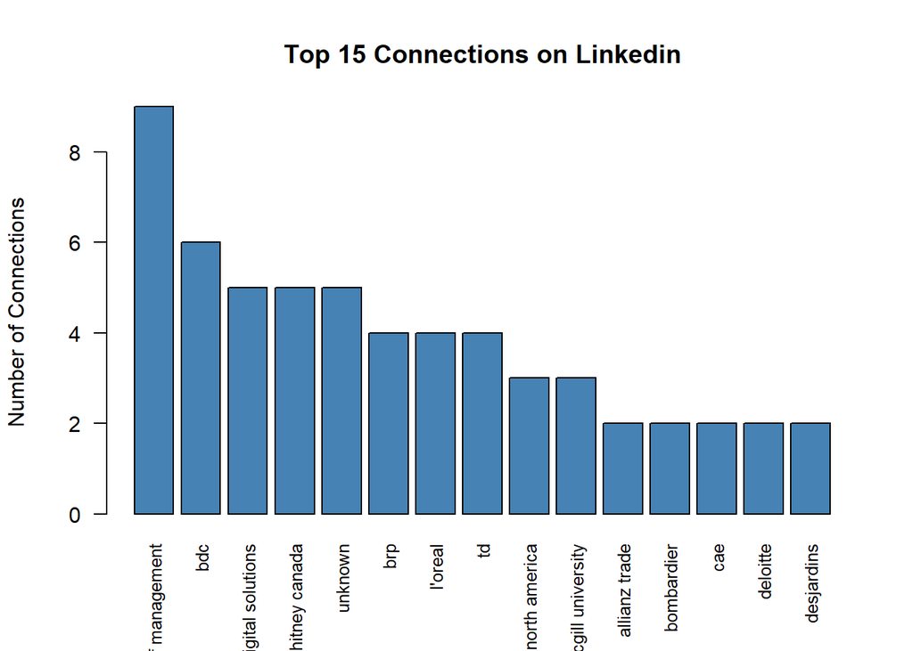

```r
# create a bar chart of the frequency table
barplot(top15, main = "Top 15 Connections on Linkedin",
         ylab = "Number of Connections",
        col = "steelblue", las = 2, cex.names = 0.8)
```

### Creating nodes

The nodes are represented by my contacts, and I am also including the companies they worked for.

```r
######### Creating nodes

library(tidyverse)
people <- cnxn %>%
  distinct(name) %>%
  rename(label = name)

companies <- cnxn %>%
  distinct(Company) %>%
  rename(label = Company)

nodes <- full_join(people, companies, by = "label")
nodes <- rowid_to_column(nodes, "id")
head(nodes)
```

```
##   id      label
## 1  1  Kritika N
## 2  2     Omar B
## 3  3 Abdullah A
## 4  4    Amjad H
## 5  5    Jawad T
## 6  6     Taju P
```

### Creating edges

The edges represent the relationship between the people and the companies.

```r
#### Creating edges

edges <- cnxn[, c("name", "Company")]

edges <- edges %>%
  left_join(nodes, by = c("name" = "label")) %>%
  rename(from = id)

edges <- edges %>%
  left_join(nodes, by = c("Company" = "label")) %>%
  rename(to = id)

edges <- unique(select(edges, from, to))
head(edges)
```

```
##   from  to
## 1    1 155
## 2    2 156
## 3    3 157
## 4    4 158
## 5    5 159
## 6    6 160
```

### Graph with network library

One can see that there are around 4 companies with the most connections. However one cannot really see the details of each.

```r
## Building network
library(network)
```

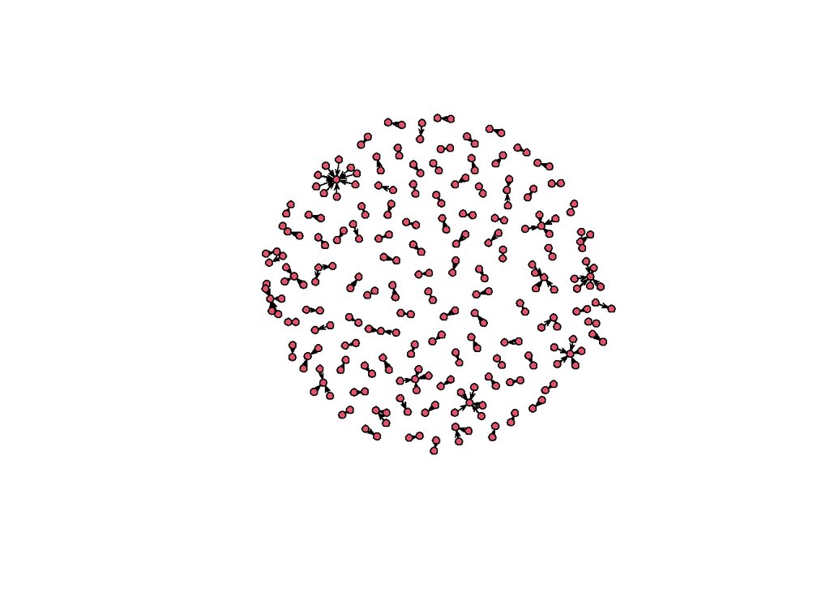

```r
routes_network <- network(edges,
                          vertex.attr = nodes,
                          matrix.type = "edgelist",
                          ignore.eval = FALSE)
plot(routes_network, vertex.cex = 1)
```

### Graph with igraph

Using igraph I added the names of companies and people, however, it is still difficult to see due to the high number of connections.

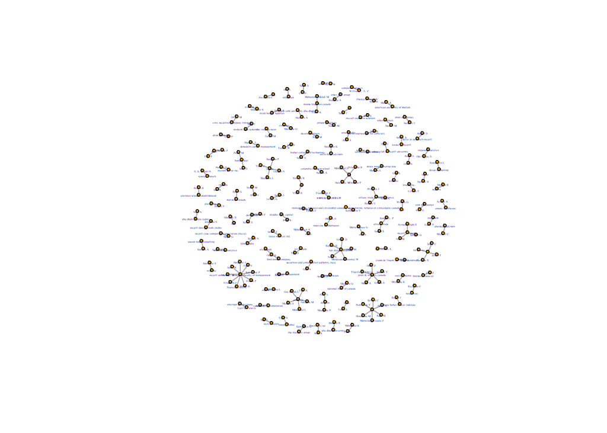

```r
## igraph

library(igraph)
routes_igraph <- graph_from_data_frame(d = edges,
                                       vertices = nodes,
                                       directed = TRUE)

plot(routes_igraph,
     vertex.size = 3,
     vertex.label.cex = 0.2,
     edge.arrow.size = 0.01)
```

### Graph with visnetwork library

visnetwork library offers an interactive network graph which enhances the visibility of company and employee names.

```r
## visNetwork

library(visNetwork)
library(networkD3)
visNetwork(nodes, edges)
```

[interactive chart not shown]